# Did States With A Stricter Governmental Response to COVID-19 Experience Worse Economic Outcomes?

Jonathan Gong, CMSC320 Final Project, May 16th, 2022

## 1. Introduction

Since the beginning of the COVID-19 pandemic, many U.S. citizens have expressed concerns about the economic repercussions resulting from the government’s policy responses. These reservations combined with inherent disagreements about the overall health risk imposed by the virus has led different state and local administrations to impose varying levels of COVID-19 restrictions in terms of both breadth and stringency. For instance, whereas Democrat-led states in the northeast tended to pass more rigorous containment policies, Republican-led states in the midwest were generally more lenient in their implementation of government measures.

However, the enforcement of COVID-19 policies was hardly uniform amongst regions. Given the United States’ federalist nature, both President Trump and President Biden’s administrations heavily relied on a decentralized approach towards combating the virus. Indeed, although federal restrictions and guidelines certainly played a role in influencing everyday Americans’ lives, the vast majority of decision-making regarding COVID-19 was left to individual state governments.

The decentralized nature of the U.S. approach resulted in a wide array of unique responses to the pandemic. The purpose of this project is to leverage this variability by examining whether states with stricter governmental responses experienced worse economic outcomes. Under the hypothesis that greater stringency translates to worse economic outcomes, I seek to identify which specific policies incurred the greatest cost and by how much. It is also plausible that reducing the spread of COVID-19 could have resulted in positive economic externalities in the long-run by fostering a quicker return to normalcy.

To accomplish this, I used monthly state-level employment and earnings measurements as well as ordinal indices from [Oxford’s COVID-19 government response tracker](https://github.com/OxCGRT/USA-covid-policy) to perform an entity fixed-effects regression. I found that the effect of higher stringency on employment was negative for some policies but small. Specifically, the policies most associated with lower employment were stricter workplace closure mandates, stay-at-home requirements, and schoolClosures, but none had a profound scalable impact. On the other hand, the association between stringency of response and average weekly earnings was generally quite week but trended upwards.

```python
import numpy as np
import pandas as pd
import statsmodels.api as sm
import matplotlib.pyplot as plt
```

## 2. Data Collection for the Independent Variables

### a) The Oxford COVID-19 Government Response Tracker

This data measures the stringency of each COVID-19 policy response for each state in the U.S. over time (January 2020 to March 2021). It was created by researchers at the Blavatnik School of Government as part of their ongoing endeavor to create the Oxford COVID-19 Government Response Tracker (an aggregatation of information regarding each government's response-level to the pandemic across the entire world). The data I am using is from their [US-specific subnational dataset](https://www.bsg.ox.ac.uk/sites/default/files/2021-05/BSG-WP-2020-034-v3.pdf). I downloaded this data directly as an Excel file from their website. Each sheet in the excel file corresponds to a different policy measure.

To measure the stringency of any given COVID-19 response policies, the researchers have designed their own system of ordinal metrics. As an example, the variable for “Workplace Closing” is encoded as follows:

0 - no measures  
1 - recommend closing (or recommend work from home) or all businesses open with alterations resulting in significant differences compared to non-COVID-19 operation.  
2 - require closing (or work from home) for some sectors or categories of workers  
3 - require closing (or work from home) for all-but-essential workplaces (e.g. grocery stores, doctors)” (“Variation in US states’ COVID-19 policy responses).

```python
# A dictionary with each key corresponding to a specific policy.
# The value for each key can be extracted as a time-series dataframe
sheet_to_df_map = pd.read_excel('/Users/jongong/School/Junior Year/CMSC320/Final Project/stringency_indices.xlsx',
                                sheet_name=None)
```

```python
# Extracting the time series data specific to each policy
school_closing_df = sheet_to_df_map['c1_school_closing']
workplace_closing_df = sheet_to_df_map['c2_workplace_closing']
restrictions_on_gathering_df = sheet_to_df_map['c4_restrictions_on_gatherings']
stay_at_home_df = sheet_to_df_map['c6_stay_at_home_requirements']
close_public_transport_df = sheet_to_df_map['c5_close_public_transport']
facial_coverings_df = sheet_to_df_map['h6_facial_coverings']

# Extracting the composite index for each state's stringency level over time
stringency_df = sheet_to_df_map['stringency_index']

policy_dfs = [school_closing_df, workplace_closing_df, restrictions_on_gathering_df, stay_at_home_df,
              close_public_transport_df, facial_coverings_df]
```

```python
# These are the list of columns to unpivot when we convert from wide to long
monthYears = ['Jan2020', 'Feb2020', 'Mar2020', 'Apr2020', 'May2020', 'Jun2020','Jul2020', 'Aug2020', 'Sep2020',
         'Oct2020', 'Nov2020', 'Dec2020', 'Jan2021', 'Feb2021', 'Mar2021']

# This is the list columns we want to extract from each policy-specific dataframe
cols = ['01' + elem for elem in monthYears]
cols = ['region_name'] + cols
```

```python
# Extracting the columns of interest (the state name and the ordinal measure of the given policy for each month)
# The way this data was provided is inherently wide in its formatting
wide_school = school_closing_df[cols].copy()
wide_workplace = workplace_closing_df[cols].copy()
wide_restrictions = restrictions_on_gathering_df[cols].copy()
wide_stay_at_home = stay_at_home_df[cols].copy()
wide_close_public_transport = close_public_transport_df[cols].copy()
wide_facial_coverings = facial_coverings_df[cols].copy()
wide_composite_index = stringency_df[cols].copy()
```

```python
# stripping 01 from all column names -- this turns the specific day into a measurement for the entire month
wide_school.columns = wide_school.columns.str.lstrip('01')
wide_workplace.columns = wide_workplace.columns.str.lstrip('01')
wide_restrictions.columns = wide_restrictions.columns.str.lstrip('01')
wide_stay_at_home.columns = wide_stay_at_home.columns.str.lstrip('01')
wide_close_public_transport.columns = wide_close_public_transport.columns.str.lstrip('01')
wide_facial_coverings.columns = wide_facial_coverings.columns.str.lstrip('01')
wide_composite_index.columns = wide_composite_index.columns.str.lstrip('01')
```

```python
# conversion from wide to long format for the eventual regression purposes
long_school = pd.melt(wide_school, id_vars = 'region_name', value_vars = monthYears,
                      var_name = 'monthYear', value_name = 'schoolClosing')

long_workplace = pd.melt(wide_workplace, id_vars = 'region_name', value_vars = monthYears,
                      var_name = 'monthYear', value_name = 'workplaceClosures')

long_restrictions = pd.melt(wide_restrictions, id_vars = 'region_name', value_vars = monthYears,
                      var_name = 'monthYear', value_name = 'restrictionsOnGathering')

long_stay = pd.melt(wide_stay_at_home, id_vars = 'region_name', value_vars = monthYears,
                      var_name = 'monthYear', value_name = 'stayAtHomeRequirements')

long_close = pd.melt(wide_close_public_transport, id_vars = 'region_name', value_vars = monthYears,
                      var_name = 'monthYear', value_name = 'closePublicTransport')

long_facial_coverings = pd.melt(wide_facial_coverings, id_vars = 'region_name', value_vars = monthYears,
                      var_name = 'monthYear', value_name = 'facialCoverings')

long_composite = pd.melt(wide_composite_index, id_vars = 'region_name', value_vars = monthYears,
                      var_name = 'monthYear', value_name = 'compositeIndex')
```

```python
# Merging all variables into one dataframe
master_df = pd.merge(long_school, long_workplace, how = 'inner', on = ['region_name', 'monthYear'])
master_df = pd.merge(master_df, long_restrictions, how = 'inner', on = ['region_name', 'monthYear'])
master_df = pd.merge(master_df, long_stay, how = 'inner', on = ['region_name', 'monthYear'])
master_df = pd.merge(master_df, long_close, how = 'inner', on = ['region_name', 'monthYear'])
master_df = pd.merge(master_df, long_facial_coverings, how = 'inner', on = ['region_name', 'monthYear'])
master_df = pd.merge(master_df, long_composite, how = 'inner', on = ['region_name', 'monthYear'])

# Removing Washington D.C. from the observations
master_df = master_df[master_df['region_name'] != 'Washington DC']

# Renaming region_name to State
master_df = master_df.rename(columns = {'region_name': 'State'})
master_df
```

|  | State | monthYear | schoolClosing | workplaceClosures | restrictionsOnGathering | stayAtHomeRequirements | closePublicTransport | facialCoverings | compositeIndex |
| --- | --- | --- | --- | --- | --- | --- | --- | --- | --- |
| 0 | Alaska | Jan2020 | 0 | 0 | 0 | 0 | 0.0 | 0 | 0.00 |
| 1 | Alabama | Jan2020 | 0 | 0 | 0 | 0 | 0.0 | 0 | 0.00 |
| 2 | Arkansas | Jan2020 | 0 | 0 | 0 | 0 | 0.0 | 0 | 0.00 |
| 3 | Arizona | Jan2020 | 0 | 0 | 0 | 0 | 0.0 | 0 | 0.00 |
| 4 | California | Jan2020 | 0 | 0 | 0 | 0 | 0.0 | 0 | 0.00 |
| ... | ... | ... | ... | ... | ... | ... | ... | ... | ... |
| 760 | Vermont | Mar2021 | 2 | 2 | 4 | 1 | 0.0 | 3 | 69.44 |
| 761 | Washington | Mar2021 | 2 | 1 | 4 | 1 | 1.0 | 3 | 62.96 |
| 762 | Wisconsin | Mar2021 | 2 | 1 | 4 | 1 | 1.0 | 3 | 56.02 |
| 763 | West Virginia | Mar2021 | 1 | 1 | 3 | 1 | 0.0 | 3 | 50.93 |
| 764 | Wyoming | Mar2021 | 1 | 1 | 4 | 1 | 2.0 | 2 | 61.11 |

750 rows × 9 columns

### b) Number of new COVID Cases as a Controlling Variable

One of the benefits of an entity fixed-effects regression is that it can control for omitted variables in panel data when the omitted variables vary across entitites but do not change over time. Therefore, if there is a variable that varies by entity and time that it is wise to control for it. One such variable for this regression analysis is the number of new COVID cases in each month. As such, I will include this data as a controlling regressor. I obtained this data from the [New York Times COVID Data Tracker](https://github.com/nytimes/covid-19-data/blob/master/us-states.csv).

```python
covid_df = pd.read_csv('/Users/jongong/School/Junior Year/CMSC320/Final Project/covid_data.csv')

# Converting the date column into datetime format
covid_df['dateTime'] = pd.to_datetime(covid_df['date'])

# Creating a separate column specifying month
covid_df['month'] = pd.DatetimeIndex(covid_df['dateTime']).month

# Creating a separate column specifying the year
covid_df['year'] = pd.DatetimeIndex(covid_df['dateTime']).year

# Grouping by the state, year, and month columns to obtain an estimate of cases for each monthYear
covid_df = covid_df.groupby(by = ['state', 'year', 'month']).sum()

# Flattening the hierarchical multi-index structure to create a long view of the data
covid_df = covid_df.reset_index()

covid_df
```

|  | state | year | month | fips | cases | deaths |
| --- | --- | --- | --- | --- | --- | --- |
| 0 | Alabama | 2020 | 3 | 19 | 6129 | 42 |
| 1 | Alabama | 2020 | 4 | 30 | 125166 | 4044 |
| 2 | Alabama | 2020 | 5 | 31 | 372033 | 14438 |
| 3 | Alabama | 2020 | 6 | 30 | 800287 | 23697 |
| 4 | Alabama | 2020 | 7 | 31 | 1918336 | 38436 |
| ... | ... | ... | ... | ... | ... | ... |
| 1503 | Wyoming | 2022 | 1 | 1736 | 4004880 | 49280 |
| 1504 | Wyoming | 2022 | 2 | 1568 | 4272079 | 47068 |
| 1505 | Wyoming | 2022 | 3 | 1736 | 4829026 | 54667 |
| 1506 | Wyoming | 2022 | 4 | 1680 | 4689884 | 54052 |
| 1507 | Wyoming | 2022 | 5 | 728 | 2038439 | 23590 |

1508 rows × 6 columns

However, this data table reflects total cases per month and I want the number of new cases by month. As such, I have to create a new incremental column using the information I have. This may result in negative observations if the total number of cases goes down in a state in a monthly period.

```python
# Creating a new column calculating the real-value change in cases by month
for index, row in covid_df.iterrows():
    if (index == 0 or covid_df.loc[index - 1, 'state'] != row['state']):
        covid_df.loc[index, 'newCases'] = row['cases']
    else:
        covid_df.loc[index, 'newCases'] = row['cases'] - covid_df.loc[index - 1, 'cases']

covid_df
```

|  | state | year | month | fips | cases | deaths | newCases |
| --- | --- | --- | --- | --- | --- | --- | --- |
| 0 | Alabama | 2020 | 3 | 19 | 6129 | 42 | 6129.0 |
| 1 | Alabama | 2020 | 4 | 30 | 125166 | 4044 | 119037.0 |
| 2 | Alabama | 2020 | 5 | 31 | 372033 | 14438 | 246867.0 |
| 3 | Alabama | 2020 | 6 | 30 | 800287 | 23697 | 428254.0 |
| 4 | Alabama | 2020 | 7 | 31 | 1918336 | 38436 | 1118049.0 |
| ... | ... | ... | ... | ... | ... | ... | ... |
| 1503 | Wyoming | 2022 | 1 | 1736 | 4004880 | 49280 | 489518.0 |
| 1504 | Wyoming | 2022 | 2 | 1568 | 4272079 | 47068 | 267199.0 |
| 1505 | Wyoming | 2022 | 3 | 1736 | 4829026 | 54667 | 556947.0 |
| 1506 | Wyoming | 2022 | 4 | 1680 | 4689884 | 54052 | -139142.0 |
| 1507 | Wyoming | 2022 | 5 | 728 | 2038439 | 23590 | -2651445.0 |

1508 rows × 7 columns

## Merging the COVID Data with the Master Dataframe

```python
# Creating a monthYear column from the covid_df dataframe
monthDict = {1: 'Jan', 2:'Feb', 3:'Mar', 4:'Apr', 5:'May', 6:'Jun',
             7:'Jul', 8:'Aug', 9:'Sep', 10:'Oct', 11:'Nov', 12:'Dec'}

# Creating a monthYear column for the eventual merge
covid_df['monthName'] = covid_df.apply(lambda row: monthDict[row['month']], axis = 1)
covid_df['monthYear'] = covid_df['monthName'] + covid_df['year'].astype(str)

# Extracting the columns of interest for the merge and trivial renaming
covid_df = covid_df[['state', 'monthYear','cases', 'newCases']]
covid_df = covid_df.rename(columns = {'state':'State'})
```

```python
# Merging the master dataframe and the covid data dataframe
master_df = pd.merge(master_df, covid_df, how = 'left', on = ['State','monthYear'])

# Filling in the missing observations with 0 because
# They correspond to entries in the covid_df that had no reported cases
master_df = master_df.fillna(0)

master_df
```

|  | State | monthYear | schoolClosing | workplaceClosures | restrictionsOnGathering | stayAtHomeRequirements | closePublicTransport | facialCoverings | compositeIndex | cases | newCases |
| --- | --- | --- | --- | --- | --- | --- | --- | --- | --- | --- | --- |
| 0 | Alaska | Jan2020 | 0 | 0 | 0 | 0 | 0.0 | 0 | 0.00 | 0.0 | 0.0 |
| 1 | Alabama | Jan2020 | 0 | 0 | 0 | 0 | 0.0 | 0 | 0.00 | 0.0 | 0.0 |
| 2 | Arkansas | Jan2020 | 0 | 0 | 0 | 0 | 0.0 | 0 | 0.00 | 0.0 | 0.0 |
| 3 | Arizona | Jan2020 | 0 | 0 | 0 | 0 | 0.0 | 0 | 0.00 | 6.0 | 6.0 |
| 4 | California | Jan2020 | 0 | 0 | 0 | 0 | 0.0 | 0 | 0.00 | 14.0 | 14.0 |
| ... | ... | ... | ... | ... | ... | ... | ... | ... | ... | ... | ... |
| 745 | Vermont | Mar2021 | 2 | 2 | 4 | 1 | 0.0 | 3 | 69.44 | 531684.0 | 147927.0 |
| 746 | Washington | Mar2021 | 2 | 1 | 4 | 1 | 1.0 | 3 | 62.96 | 10991162.0 | 1707470.0 |
| 747 | Wisconsin | Mar2021 | 2 | 1 | 4 | 1 | 1.0 | 3 | 56.02 | 19431653.0 | 2444086.0 |
| 748 | West Virginia | Mar2021 | 1 | 1 | 3 | 1 | 0.0 | 3 | 50.93 | 4227093.0 | 663861.0 |
| 749 | Wyoming | Mar2021 | 1 | 1 | 4 | 1 | 2.0 | 2 | 61.11 | 1716641.0 | 225347.0 |

750 rows × 11 columns

## 3. Data Collection for the Dependent Variables

### a) Employment Data

The first dependent variable I want to predict is employment. To do this, I needed monthly employment data from January 2020 to March 2021. This is the same period of time that Oxford COVID-19 Government Response Tracker spans. I collected this data by using the [U.S. Bureau of Labor Statistic's Employment and Wages Data Viewer](https://data.bls.gov/cew/apps/data_views/data_views.htm#tab=Tables) to create 5 custom data tables corresponding to each quarter in 2020 and the first quarter in 2021. I aggregated the 15 employment columns into a excel file by hand through copy-paste (this is the only time in this project I don't use Pandas to manipulate the data as it was faster than importing and merging 5 separate files), which I subsequently downloaded as a CSV to be imported via pd.read_csv() below.

```python
monthly_employment = pd.read_csv('/Users/jongong/School/Junior Year/CMSC320/Final Project/unemployment_2020_2021.csv')
long_employment = pd.melt(monthly_employment, id_vars = 'State', value_vars = monthYears,
                         var_name = 'monthYear', value_name = 'employment')
long_employment
```

|  | State | monthYear | employment |
| --- | --- | --- | --- |
| 0 | Alabama | Jan2020 | 1975812.0 |
| 1 | Alaska | Jan2020 | 306487.0 |
| 2 | Arizona | Jan2020 | 2965780.0 |
| 3 | Arkansas | Jan2020 | 1214487.0 |
| 4 | California | Jan2020 | 17609773.0 |
| ... | ... | ... | ... |
| 760 | Virginia | Mar2021 | 3773832.0 |
| 761 | Washington | Mar2021 | 3252871.0 |
| 762 | West Virginia | Mar2021 | 649399.0 |
| 763 | Wisconsin | Mar2021 | 2735355.0 |
| 764 | Wyoming | Mar2021 | 256889.0 |

765 rows × 3 columns

### b) Average Weekly Earnings

The second dependent variable I want to predict is average weekly earnings. I collected this data from the [The Urban Institute's State Economic Monitor](https://apps.urban.org/features/state-economic-monitor/). The CSV file downloaded in the cell below is a file that I was able to download directly from their source data folders.

```python
average_weekly_earnings = pd.read_csv('/Users/jongong/School/Junior Year/CMSC320/Final Project/weekly_earnings_raw.csv')

# Extracting the columns of interest
average_weekly_earnings = average_weekly_earnings[['Geography','2020-01-01','2020-02-01', '2020-03-01',
                                                  '2020-04-01','2020-05-01', '2020-06-01', '2020-07-01',
                                                  '2020-08-01','2020-09-01', '2020-10-01', '2020-11-01',
                                                  '2020-12-01','2021-01-01', '2021-02-01', '2021-03-01']]
# Extracting the rows of interest
average_weekly_earnings = average_weekly_earnings[average_weekly_earnings['Geography'] != 'United States']
average_weekly_earnings = average_weekly_earnings[average_weekly_earnings['Geography'] != 'District of Columbia']

col_dict = {'Geography': 'State', '2020-01-01':'Jan2020','2020-02-01':'Feb2020', '2020-03-01':'Mar2020',
            '2020-04-01':'Apr2020','2020-05-01':'May2020', '2020-06-01':'Jun2020', '2020-07-01':'Jul2020',
            '2020-08-01':'Aug2020','2020-09-01':'Sep2020', '2020-10-01':'Oct2020', '2020-11-01':'Nov2020',
            '2020-12-01':'Dec2020','2021-01-01':'Jan2021', '2021-02-01':'Feb2021', '2021-03-01':'Mar2021'}

# Renaming columns to match independent variable format for eventual merge
average_weekly_earnings = average_weekly_earnings.rename(columns = col_dict).reset_index(drop = True)

# Converting from wide to long format
long_avg_wkly_earnings = pd.melt(average_weekly_earnings, id_vars = 'State', value_vars = monthYears,
                      var_name = 'monthYear', value_name = 'avgWklyEarnings')

long_avg_wkly_earnings
```

|  | State | monthYear | avgWklyEarnings |
| --- | --- | --- | --- |
| 0 | Alabama | Jan2020 | 972.385423 |
| 1 | Alaska | Jan2020 | 1137.362173 |
| 2 | Arizona | Jan2020 | 1041.984815 |
| 3 | Arkansas | Jan2020 | 881.989799 |
| 4 | California | Jan2020 | 1256.890352 |
| ... | ... | ... | ... |
| 745 | Virginia | Mar2021 | 1132.477710 |
| 746 | Washington | Mar2021 | 1290.700047 |
| 747 | West Virginia | Mar2021 | 956.367576 |
| 748 | Wisconsin | Mar2021 | 1007.349967 |
| 749 | Wyoming | Mar2021 | 987.030820 |

750 rows × 3 columns

## Standardization for the Dependent Variables

I will eventually be regressing the above data (employment and average weekly earnings) upon metrics of stringency. To account for the inherent differences in the economic capabilities of each state, I want to standardize the dependent variables by dividing by 2020 state-population totals as well as 2019 Q4 state-GDP (as a measure of pre-COVID output levels). I collected the population data from the [US Census Bureau's "State. Population Totals and Components of Change: 2020-2021"](https://www.census.gov/data/datasets/time-series/demo/popest/2020s-state-total.html#par_textimage_1873399417) data page. I collected State Q4 GDP Levels from the [US Bureau of Economic Analysis Archives](https://apps.bea.gov/regional/histdata/releases/0420gdpstate/index.cfm).

```python
# Population Data
pop_by_state = pd.read_csv('/Users/jongong/School/Junior Year/CMSC320/Final Project/NST-EST2021-alldata.csv')

# Extracting on the columns of interest
pop_by_state = pop_by_state[['NAME', 'POPESTIMATE2020']]

# Removing aggregate regional observations from the dataset
pop_by_state = pop_by_state[pop_by_state['NAME'] != 'United States']
pop_by_state = pop_by_state[pop_by_state['NAME'] != 'Northeast Region']
pop_by_state = pop_by_state[pop_by_state['NAME'] != 'Midwest Region']
pop_by_state = pop_by_state[pop_by_state['NAME'] != 'South Region']
pop_by_state = pop_by_state[pop_by_state['NAME'] != 'West Region']

# Removing Puerto Rico and Washington D.C. from the dataset for consistency
pop_by_state = pop_by_state[pop_by_state['NAME'] != 'Puerto Rico']
pop_by_state = pop_by_state[pop_by_state['NAME'] != 'District of Columbia']
pop_by_state = pop_by_state.rename(columns = {'NAME':'State'}).reset_index(drop = True)
pop_by_state.head()
```

|  | State | POPESTIMATE2020 |
| --- | --- | --- |
| 0 | Alabama | 5024803 |
| 1 | Alaska | 732441 |
| 2 | Arizona | 7177986 |
| 3 | Arkansas | 3012232 |
| 4 | California | 39499738 |

```python
# Q4 GDP Data
gdp_by_state = pd.read_csv('/Users/jongong/School/Junior Year/CMSC320/Final Project/SQGDP1__ALL_AREAS_2005_2019.csv')

# Extracting only the columns of interest
gdp_by_state = gdp_by_state[['GeoName', 'Description','2019:Q4']]

# Extracting only the rows of interest
gdp_by_state = gdp_by_state[gdp_by_state['Description'] == 'Real GDP (millions of chained 2012 dollars)']

unwanted_obs = ['United States', 'District of Columbia', 'New England', 'Mideast', 'Great Lakes',
               'Plains', 'Southeast', 'Southwest', 'Rocky Mountain', 'Far West']

for obs in unwanted_obs:
    gdp_by_state = gdp_by_state[gdp_by_state['GeoName'] != obs]


# Final trivial cleaning
gdp_by_state = gdp_by_state[['GeoName', '2019:Q4']].reset_index(drop = True)
gdp_by_state = gdp_by_state.rename(columns = {'GeoName': 'State', '2019:Q4':'2019_Q4_GDP'})
gdp_by_state.head()
```

|  | State | 2019_Q4_GDP |
| --- | --- | --- |
| 0 | Alabama | 204484.3 |
| 1 | Alaska | 54786.0 |
| 2 | Arizona | 324915.4 |
| 3 | Arkansas | 120535.7 |
| 4 | California | 2813699.0 |

### Adding Dependent and Standardizing Variables to the Master Dataframe

```python
# Adding Employment Data
master_df = master_df.merge(long_employment, how = 'left', on = ['State', 'monthYear'])

# Adding Weekly Average Earnings Data
master_df = master_df.merge(long_avg_wkly_earnings, how = 'left', on = ['State', 'monthYear'])

# Adding Population and GDP by State
master_df = master_df.merge(pop_by_state, how = 'left', on = 'State')
master_df = master_df.merge(gdp_by_state, how = 'left', on = 'State')
```

```python
# Creating the standardized dependent variable factoring in population
master_df['emplPopRatio'] = master_df['employment'] / master_df['POPESTIMATE2020']

# Creating the standardized dependent variable factoring in GDP
# I multiply by 10,000 because the original GDP column is in millions of dollars (it will be in the denominator)
# and I will eventually multiply by 100 to obtain the percentage figure
master_df['emplGDPRatio'] = master_df['employment'] / (master_df['2019_Q4_GDP'])
master_df
```

|  | State | monthYear | schoolClosing | workplaceClosures | restrictionsOnGathering | stayAtHomeRequirements | closePublicTransport | facialCoverings | compositeIndex | cases | newCases | employment | avgWklyEarnings | POPESTIMATE2020 | 2019_Q4_GDP | emplPopRatio | emplGDPRatio |
| --- | --- | --- | --- | --- | --- | --- | --- | --- | --- | --- | --- | --- | --- | --- | --- | --- | --- |
| 0 | Alaska | Jan2020 | 0 | 0 | 0 | 0 | 0.0 | 0 | 0.00 | 0.0 | 0.0 | 306487.0 | 1137.362173 | 732441 | 54786.0 | 0.418446 | 5.594258 |
| 1 | Alabama | Jan2020 | 0 | 0 | 0 | 0 | 0.0 | 0 | 0.00 | 0.0 | 0.0 | 1975812.0 | 972.385423 | 5024803 | 204484.3 | 0.393212 | 9.662414 |
| 2 | Arkansas | Jan2020 | 0 | 0 | 0 | 0 | 0.0 | 0 | 0.00 | 0.0 | 0.0 | 1214487.0 | 881.989799 | 3012232 | 120535.7 | 0.403185 | 10.075745 |
| 3 | Arizona | Jan2020 | 0 | 0 | 0 | 0 | 0.0 | 0 | 0.00 | 6.0 | 6.0 | 2965780.0 | 1041.984815 | 7177986 | 324915.4 | 0.413177 | 9.127853 |
| 4 | California | Jan2020 | 0 | 0 | 0 | 0 | 0.0 | 0 | 0.00 | 14.0 | 14.0 | 17609773.0 | 1256.890352 | 39499738 | 2813699.0 | 0.445820 | 6.258585 |
| ... | ... | ... | ... | ... | ... | ... | ... | ... | ... | ... | ... | ... | ... | ... | ... | ... | ... |
| 745 | Vermont | Mar2021 | 2 | 2 | 4 | 1 | 0.0 | 3 | 69.44 | 531684.0 | 147927.0 | 284765.0 | 1014.969648 | 642495 | 30704.9 | 0.443217 | 9.274253 |
| 746 | Washington | Mar2021 | 2 | 1 | 4 | 1 | 1.0 | 3 | 62.96 | 10991162.0 | 1707470.0 | 3252871.0 | 1290.700047 | 7718785 | 537642.2 | 0.421423 | 6.050252 |
| 747 | Wisconsin | Mar2021 | 2 | 1 | 4 | 1 | 1.0 | 3 | 56.02 | 19431653.0 | 2444086.0 | 2735355.0 | 1007.349967 | 5892323 | 307883.7 | 0.464224 | 8.884377 |
| 748 | West Virginia | Mar2021 | 1 | 1 | 3 | 1 | 0.0 | 3 | 50.93 | 4227093.0 | 663861.0 | 649399.0 | 956.367576 | 1789798 | 72264.2 | 0.362834 | 8.986455 |
| 749 | Wyoming | Mar2021 | 1 | 1 | 4 | 1 | 2.0 | 2 | 61.11 | 1716641.0 | 225347.0 | 256889.0 | 987.030820 | 577267 | 39472.9 | 0.445009 | 6.507984 |

750 rows × 17 columns

## 4. Data Visualization

### Scatterplot of Composite Index Against Employment

The first graph I am interested in seeing is the relationship between the composite stringency index for each state in each monthYear with the economic outcomes of that state. The composite index is an aggregate measure of all policy responses (going beyond the ones that I handpicked). It ranges on a scale of zero to one-hundred.

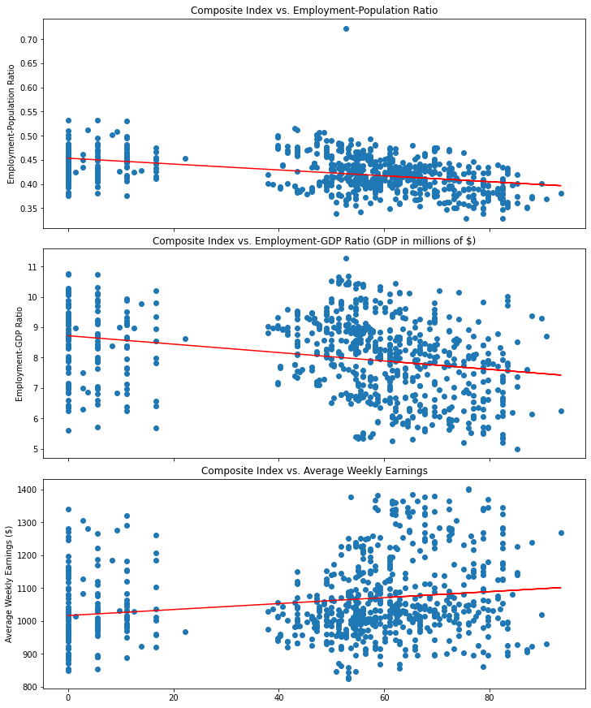

```python
fig, axs = plt.subplots(3, 1, constrained_layout = True, sharex = True, figsize = (10, 12))
axs[0].scatter(master_df['compositeIndex'], master_df['emplPopRatio'])
axs[0].set_title('Composite Index vs. Employment-Population Ratio')
m1, b1 = np.polyfit(master_df['compositeIndex'], master_df['emplPopRatio'], 1)
axs[0].set_ylabel('Employment-Population Ratio')
axs[0].plot(master_df['compositeIndex'], master_df['compositeIndex']*m1 + b1, color = 'red')

axs[1].scatter(master_df['compositeIndex'], master_df['emplGDPRatio'])
axs[1].set_title('Composite Index vs. Employment-GDP Ratio (GDP in millions of $)')
m2, b2 = np.polyfit(master_df['compositeIndex'], master_df['emplGDPRatio'], 1)
axs[1].set_ylabel('Employment-GDP Ratio')
axs[1].plot(master_df['compositeIndex'], master_df['compositeIndex']*m2 + b2, color = 'red')

axs[2].scatter(master_df['compositeIndex'], master_df['avgWklyEarnings'])
axs[2].set_title('Composite Index vs. Average Weekly Earnings')
m3, b3 = np.polyfit(master_df['compositeIndex'], master_df['avgWklyEarnings'], 1)
axs[2].set_ylabel('Average Weekly Earnings ($)')
_ = axs[2].plot(master_df['compositeIndex'], master_df['compositeIndex']*m3 + b3, color = 'red')
```

There are two main insights apparent from these graph.

1. There appears to be a stark contrast between observations that can be characteried as "low stringency" and observations that can be characterized as "high stringency." In other words, it is not common for a state to have exhibited a medium (20-40) level of stringency at any given time. This natural disparity could be due to the tendency of some states to never reach a high level of stringency (i.e. low-enforcement Republican-leaning states). Alternatively, all states might have exhibited a jump in their stringency level (i.e. after shutdowns occured). The former is presumably more likely given the insights of the Oxford COVID-19 Tracker Study.
2. The overall correlation between stringency and employment seems to be fairly weak but negative. As the index for stringency increases, the employment-population ratio trends downwards but there are high residuals across the board. By contrast, the relationship is slightly upwards trending for average weekly earnings but the correlation remains fairly weak.

The only observable difference between the population and GDP standardization methods is that the GDP standardization method appears to eliminate the occurence of one extreme outlier around the 50 ticker for the x-axis. This indicates that the GDP standardization method may be better for regression analysis

## Violin Plots for COVID-19 Policies

### a) Workplace Closures

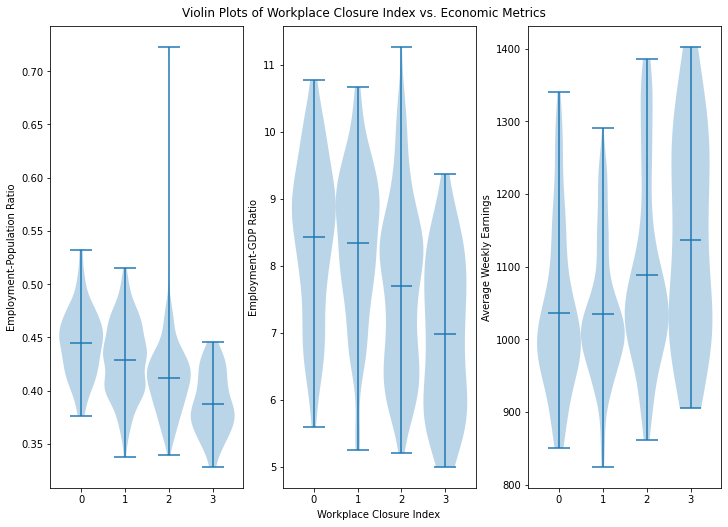

```python
# Obtaining an array of unique indicies values
wp_indices = master_df['workplaceClosures'].unique()
emplPopRatio_by_wp_index = []
emplGDPRatio_by_wp_index = []
avg_wkly_earnings_by_wp_index = []

for index in wp_indices:
    emplPopRatio_by_wp_index.append(master_df[master_df['workplaceClosures']==index]['emplPopRatio'])
    emplGDPRatio_by_wp_index.append(master_df[master_df['workplaceClosures']==index]['emplGDPRatio'])
    avg_wkly_earnings_by_wp_index.append(master_df[master_df['workplaceClosures']==index]['avgWklyEarnings'])


fig, axs = plt.subplots(1,3, constrained_layout = True, figsize = (10, 7))
fig.suptitle('Violin Plots of Workplace Closure Index vs. Economic Metrics')
fig.text(0.52, -.02, 'Workplace Closure Index', ha = 'center')
axs[0].violinplot(emplPopRatio_by_wp_index, wp_indices, widths = 1, showmeans=True)
axs[0].set_ylabel('Employment-Population Ratio')

axs[1].violinplot(emplGDPRatio_by_wp_index, wp_indices, widths = 1, showmeans=True)
axs[1].set_ylabel('Employment-GDP Ratio')

axs[2].violinplot(avg_wkly_earnings_by_wp_index, wp_indices, widths = 1, showmeans=True)
_ = axs[2].set_ylabel('Average Weekly Earnings')
```

There seems to be a negative relationship between the stringency of workplace closures and the employment of a state. The relationsip is slightly upwards when it comes to average weekly earnings. The third graph could be indicative of reverse causality: states with a stricter response to COVID (and thereby lower employment metrics) might have received more monthly stimulus payments/unemployment aid. This would explain the potentially positive relationship between the stringency of workplace closures and average weekly earnings.

### b) Stay At Home Requirements

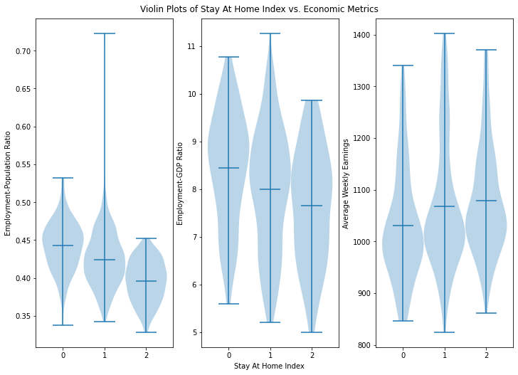

```python
# Obtaining an array of unique indicies values
sah_indices = master_df['stayAtHomeRequirements'].unique()
emplPopRatio_by_sah_index = []
emplGDPRatio_by_sah_index = []
avg_wkly_earnings_by_sah_index = []

for index in sah_indices:
    emplPopRatio_by_sah_index.append(master_df[master_df['stayAtHomeRequirements']==index]['emplPopRatio'])
    emplGDPRatio_by_sah_index.append(master_df[master_df['stayAtHomeRequirements']==index]['emplGDPRatio'])
    avg_wkly_earnings_by_sah_index.append(master_df[master_df['stayAtHomeRequirements']==index]['avgWklyEarnings'])


fig, axs = plt.subplots(1,3, constrained_layout = True, figsize = (10, 7))
fig.suptitle('Violin Plots of Stay At Home Index vs. Economic Metrics')
fig.text(0.52, -.02, 'Stay At Home Index', ha = 'center')
axs[0].violinplot(emplPopRatio_by_sah_index, sah_indices, widths = 1, showmeans=True)
axs[0].set_ylabel('Employment-Population Ratio')

axs[1].violinplot(emplGDPRatio_by_sah_index, sah_indices, widths = 1, showmeans=True)
axs[1].set_ylabel('Employment-GDP Ratio')

axs[2].violinplot(avg_wkly_earnings_by_sah_index, sah_indices, widths = 1, showmeans=True)
_ = axs[2].set_ylabel('Average Weekly Earnings')
```

These violin plots indicates that there is a negative association between the stringency of stay-at-home policies and emploment. This is not necessarily the case for Average Weekly Earnings, where the trend is actually slightly upwards (however, this correlation is much less clear).

### c) School Closures

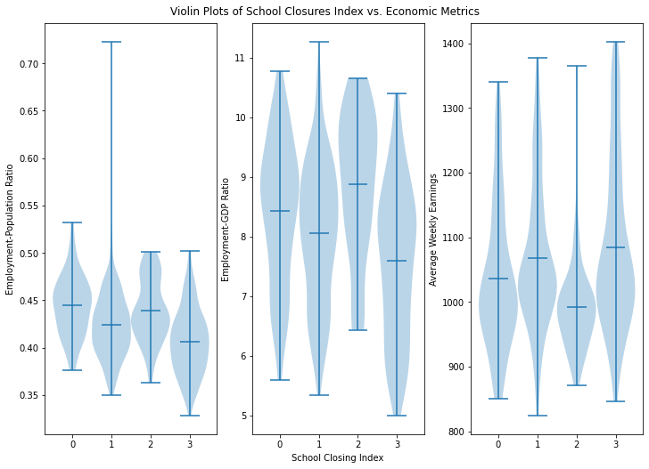

```python
# Obtaining an array of unique indicies values
sc_indices = master_df['schoolClosing'].unique()
emplPopRatio_by_sc_index = []
emplGDPRatio_by_sc_index = []
avg_wkly_earnings_by_sc_index = []

for index in wp_indices:
    emplPopRatio_by_sc_index.append(master_df[master_df['schoolClosing']==index]['emplPopRatio'])
    emplGDPRatio_by_sc_index.append(master_df[master_df['schoolClosing']==index]['emplGDPRatio'])
    avg_wkly_earnings_by_sc_index.append(master_df[master_df['schoolClosing']==index]['avgWklyEarnings'])


fig, axs = plt.subplots(1,3, constrained_layout = True, figsize = (10, 7))
fig.suptitle('Violin Plots of School Closures Index vs. Economic Metrics')
fig.text(0.52, -.02, 'School Closing Index', ha = 'center')

axs[0].violinplot(emplPopRatio_by_sc_index, sc_indices, widths = 1, showmeans=True)
axs[0].set_ylabel('Employment-Population Ratio')

axs[1].violinplot(emplGDPRatio_by_sc_index, sc_indices, widths = 1, showmeans=True)
axs[1].set_ylabel('Employment-GDP Ratio')

axs[2].violinplot(avg_wkly_earnings_by_sc_index, sc_indices, widths = 1, showmeans=True)
_ = axs[2].set_ylabel('Average Weekly Earnings')
```

The trends for school closures seem much less clear than the previous two graphs. As the stringency of school closures increased, the employment metrics generally trend downwards except for when the index is 2. This deviance is also the case for Average Weekly Earnings, except the direction is opposite.

### d) Restrictions On Gathering

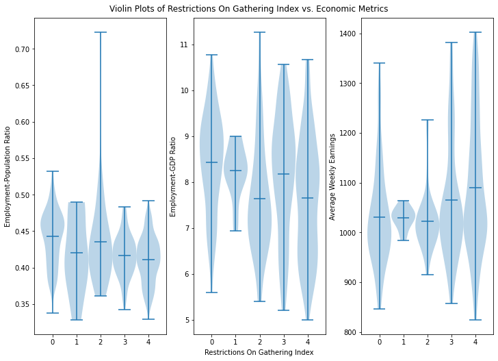

```python
# Obtaining an array of unique indicies values
rog_indices = master_df['restrictionsOnGathering'].unique()
emplPopRatio_by_rog_index = []
emplGDPRatio_by_rog_index = []
avg_wkly_earnings_by_rog_index = []

# Extracting an array of each index for each economic output metric
for index in rog_indices:
    emplPopRatio_by_rog_index.append(master_df[master_df['restrictionsOnGathering']==index]['emplPopRatio'])
    emplGDPRatio_by_rog_index.append(master_df[master_df['restrictionsOnGathering']==index]['emplGDPRatio'])
    avg_wkly_earnings_by_rog_index.append(master_df[master_df['restrictionsOnGathering']==index]['avgWklyEarnings'])


fig, axs = plt.subplots(1,3, constrained_layout = True, sharex = True, figsize = (10, 7))

# Common X-Axis
fig.text(0.52, -.02, 'Restrictions On Gathering Index', ha = 'center')

fig.suptitle('Violin Plots of Restrictions On Gathering Index vs. Economic Metrics')
axs[0].violinplot(emplPopRatio_by_rog_index, rog_indices, widths = 1, showmeans=True)
axs[0].set_ylabel('Employment-Population Ratio')

axs[1].violinplot(emplGDPRatio_by_rog_index, rog_indices, widths = 1, showmeans=True)
axs[1].set_ylabel('Employment-GDP Ratio')

axs[2].violinplot(avg_wkly_earnings_by_rog_index, rog_indices, widths = 1, showmeans=True)
_ = axs[2].set_ylabel('Average Weekly Earnings')
```

The graphs for restrictionsOnGathering follow the same trend as workplaceClosures. There seems to be a negative relationship (albeit less pronounced) between the policy index and the employment outcomes. Conversely, as the indices increased the averagely weekly earnings also seem to increase.

### e) Closing Public Transport

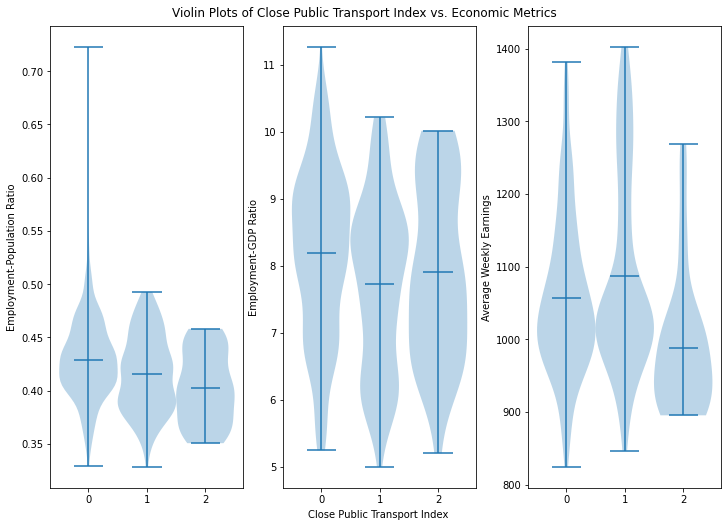

```python
# Obtaining an array of unique indicies values
cpt_indices = master_df['closePublicTransport'].unique()
emplPopRatio_by_cpt_index = []
emplGDPRatio_by_cpt_index = []
avg_wkly_earnings_by_cpt_index = []

# Extracting an array of each index for each economic output metric
for index in cpt_indices:
    emplPopRatio_by_cpt_index.append(master_df[master_df['closePublicTransport']==index]['emplPopRatio'])
    emplGDPRatio_by_cpt_index.append(master_df[master_df['closePublicTransport']==index]['emplGDPRatio'])
    avg_wkly_earnings_by_cpt_index.append(master_df[master_df['closePublicTransport']==index]['avgWklyEarnings'])


fig, axs = plt.subplots(1,3, constrained_layout = True, sharex = True, figsize = (10, 7))

# Common X-Axis
fig.text(0.52, -.02, 'Close Public Transport Index', ha = 'center')

fig.suptitle('Violin Plots of Close Public Transport Index vs. Economic Metrics')
axs[0].violinplot(emplPopRatio_by_cpt_index, cpt_indices, widths = 1, showmeans=True)
axs[0].set_ylabel('Employment-Population Ratio')

axs[1].violinplot(emplGDPRatio_by_cpt_index, cpt_indices, widths = 1, showmeans=True)
axs[1].set_ylabel('Employment-GDP Ratio')

axs[2].violinplot(avg_wkly_earnings_by_cpt_index, cpt_indices, widths = 1, showmeans=True)
_ = axs[2].set_ylabel('Average Weekly Earnings')
```

There is not a clear discernible relationship between the stringency to which a state closed public transport and employment measures. The same goes for Average Weekly Earnings.

### f) Facial Coverings

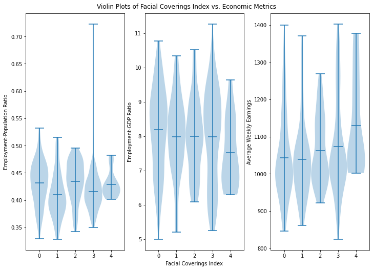

```python
# Obtaining an array of unique indicies values
fc_indices = master_df['facialCoverings'].unique()
emplPopRatio_by_fc_index = []
emplGDPRatio_by_fc_index = []
avg_wkly_earnings_by_fc_index = []

# Extracting an array of each index for each economic output metric
for index in fc_indices:
    emplPopRatio_by_fc_index.append(master_df[master_df['facialCoverings']==index]['emplPopRatio'])
    emplGDPRatio_by_fc_index.append(master_df[master_df['facialCoverings']==index]['emplGDPRatio'])
    avg_wkly_earnings_by_fc_index.append(master_df[master_df['facialCoverings']==index]['avgWklyEarnings'])


fig, axs = plt.subplots(1,3, constrained_layout = True, sharex = True, figsize = (10, 7))

# Common X-Axis
fig.text(0.52, -.02, 'Facial Coverings Index', ha = 'center')

fig.suptitle('Violin Plots of Facial Coverings Index vs. Economic Metrics')
axs[0].violinplot(emplPopRatio_by_fc_index, fc_indices, widths = 1, showmeans=True)
axs[0].set_ylabel('Employment-Population Ratio')

axs[1].violinplot(emplGDPRatio_by_fc_index, fc_indices, widths = 1, showmeans=True)
axs[1].set_ylabel('Employment-GDP Ratio')

axs[2].violinplot(avg_wkly_earnings_by_fc_index, fc_indices, widths = 1, showmeans=True)
_ = axs[2].set_ylabel('Average Weekly Earnings')
```

Similar to ClosePublicTransport, there does not seem to be a clear relationship between the stringency of mask mandates and employment. There does to be a slight upwards trend in regards to Average Weekly Earnings, but this might still be to the reverse causality posited after the graphs in (a).

### Initial Impressions of the Policy Specific Graphs

The policies that seem most likely to have a negative impact on employment are Workplace Closures, Stay At Home Requirements, and Restrictions on Gathering. Regarding average weekly earnings, the trend seems slightly upwards for some of the policies. This might be due to lurking variables in regards to unemployment benefits as well as stimulus check payments.

## 5. Preparing for the Regression Analysis

### Why Fixed Regression?

The reason why I chose a fixed-effects model as opposed to typical Ordinary Least Squares (OLS) is twofold. First, since the determinants of economic outcomes such as unemployment vary heavily depending on what state you are in, OLS regression would undoubtedly suffer from correlation between the explanatory variables and the error term (otherwise known as endogeneity). This would cause bias in the eventual coefficient estimates as the inherent noise of measuring at a state-level would be difficult to control for.

Second, fixed effects regression is a method for controlling for omitted variables in panel data when the omitted variables vary across entities but do not change over time. It is typical to use this model for entities such as U.S. states, where numerous factors differ across states but remain relatively constant over short periods of time (i.e. race composition, educational attainment, etc). Fixed effects regression is accomplished by creating additional binary variables for each unique entity in the dataset. These markers serve to capture any state-specific effects so that the true correlation between the explanatory variables and the dependent variables can be observed in an abstract sense. This approach is particularly useful to control for variables that are difficult to collect data for. Examples of such variables in the context of this project include regional attitudes towards COVID-19 containment policies and demographic data by month.

A reference I used: https://timeseriesreasoning.com/contents/the-fixed-effects-regression-model-for-panel-data-sets/

```python
# In order to conduct an entity and fixed effects regression,
# I need to create binary variables corresponding to each monthYear and each state.
# Importantly, I must not create a binary variables for each entity/time observation
# as this would lead to perfect multicollinearity. As such, I will create 49 entity-specific
# binary variables and 14 time-specific variables.

states = ['Alaska', 'Alabama', 'Arkansas', 'Arizona', 'California', 'Colorado', 'Connecticut', 'Delaware', 'Florida', 'Georgia', 'Hawaii', 'Iowa', 'Idaho',
          'Illinois', 'Indiana', 'Kansas', 'Kentucky', 'Louisiana', 'Massachusetts',
          'Maryland', 'Maine', 'Michigan', 'Minnesota', 'Missouri', 'Mississippi',
          'Montana', 'North Carolina', 'North Dakota', 'Nebraska', 'New Hampshire',
          'New Jersey', 'New Mexico', 'Nevada', 'New York', 'Ohio', 'Oklahoma', 'Oregon',
          'Pennsylvania', 'Rhode Island', 'South Carolina', 'South Dakota', 'Tennessee',
          'Texas', 'Utah', 'Virginia', 'Vermont', 'Washington', 'Wisconsin', 'West Virginia', 'Wyoming']

for state in states:
    if (state != 'Alaska'):
        master_df['is' + state] = np.where(master_df['State'] == state, 1, 0)

for monthYear in monthYears:
    if (monthYear != 'Jan2020'):
        master_df['is' + monthYear] = np.where(master_df['monthYear'] == monthYear, 1, 0)

master_df
```

|  | State | monthYear | schoolClosing | workplaceClosures | restrictionsOnGathering | stayAtHomeRequirements | closePublicTransport | facialCoverings | compositeIndex | cases | ... | isJun2020 | isJul2020 | isAug2020 | isSep2020 | isOct2020 | isNov2020 | isDec2020 | isJan2021 | isFeb2021 | isMar2021 |
| --- | --- | --- | --- | --- | --- | --- | --- | --- | --- | --- | --- | --- | --- | --- | --- | --- | --- | --- | --- | --- | --- |
| 0 | Alaska | Jan2020 | 0 | 0 | 0 | 0 | 0.0 | 0 | 0.00 | 0.0 | ... | 0 | 0 | 0 | 0 | 0 | 0 | 0 | 0 | 0 | 0 |
| 1 | Alabama | Jan2020 | 0 | 0 | 0 | 0 | 0.0 | 0 | 0.00 | 0.0 | ... | 0 | 0 | 0 | 0 | 0 | 0 | 0 | 0 | 0 | 0 |
| 2 | Arkansas | Jan2020 | 0 | 0 | 0 | 0 | 0.0 | 0 | 0.00 | 0.0 | ... | 0 | 0 | 0 | 0 | 0 | 0 | 0 | 0 | 0 | 0 |
| 3 | Arizona | Jan2020 | 0 | 0 | 0 | 0 | 0.0 | 0 | 0.00 | 6.0 | ... | 0 | 0 | 0 | 0 | 0 | 0 | 0 | 0 | 0 | 0 |
| 4 | California | Jan2020 | 0 | 0 | 0 | 0 | 0.0 | 0 | 0.00 | 14.0 | ... | 0 | 0 | 0 | 0 | 0 | 0 | 0 | 0 | 0 | 0 |
| ... | ... | ... | ... | ... | ... | ... | ... | ... | ... | ... | ... | ... | ... | ... | ... | ... | ... | ... | ... | ... | ... |
| 745 | Vermont | Mar2021 | 2 | 2 | 4 | 1 | 0.0 | 3 | 69.44 | 531684.0 | ... | 0 | 0 | 0 | 0 | 0 | 0 | 0 | 0 | 0 | 1 |
| 746 | Washington | Mar2021 | 2 | 1 | 4 | 1 | 1.0 | 3 | 62.96 | 10991162.0 | ... | 0 | 0 | 0 | 0 | 0 | 0 | 0 | 0 | 0 | 1 |
| 747 | Wisconsin | Mar2021 | 2 | 1 | 4 | 1 | 1.0 | 3 | 56.02 | 19431653.0 | ... | 0 | 0 | 0 | 0 | 0 | 0 | 0 | 0 | 0 | 1 |
| 748 | West Virginia | Mar2021 | 1 | 1 | 3 | 1 | 0.0 | 3 | 50.93 | 4227093.0 | ... | 0 | 0 | 0 | 0 | 0 | 0 | 0 | 0 | 0 | 1 |
| 749 | Wyoming | Mar2021 | 1 | 1 | 4 | 1 | 2.0 | 2 | 61.11 | 1716641.0 | ... | 0 | 0 | 0 | 0 | 0 | 0 | 0 | 0 | 0 | 1 |

750 rows × 80 columns

## 6. Multivariate Regression

```python
# creating an array of values corresponding to the column names for the entity-specific regressors
entity_fixed_effects = ['is' + state for state in states if state != 'Alaska']

# specifying the independent variables (controlling and explanatory) that I am interested in regressing upon
ivs = ['schoolClosing', 'workplaceClosures', 'restrictionsOnGathering', 'stayAtHomeRequirements',
       'closePublicTransport', 'facialCoverings','newCases']

iv_columns = ivs + entity_fixed_effects
x = master_df[iv_columns]
```

### a) Employment-Population Ratio

$$\widehat{EmplPop Ratio} = \alpha + \beta_1 \cdot schoolClosing + \beta_2 \cdot workplaceClosures + \beta_3 \cdot restrictionsOnGathering + \beta_4 \cdot stayAtHomeRequirements + \beta_4 \cdot closePublicTransport + \beta_5 \cdot facialCoverings + \beta_4 \cdot newCases + \beta_{i = 1...49} \cdot StateFixed Effects $$

```python
y = master_df['emplPopRatio']
x = sm.add_constant(x)
mod = sm.OLS(y, x).fit()
mod.summary()
```

OLS Regression Results

| Dep. Variable: | emplPopRatio | R-squared: | 0.876 |
| --- | --- | --- | --- |
| Model: | OLS | Adj. R-squared: | 0.865 |
| Method: | Least Squares | F-statistic: | 87.05 |
| Date: | Mon, 16 May 2022 | Prob (F-statistic): | 7.42e-275 |
| Time: | 14:25:10 | Log-Likelihood: | 2174.3 |
| No. Observations: | 750 | AIC: | -4235. |
| Df Residuals: | 693 | BIC: | -3971. |
| Df Model: | 56 |  |  |
| Covariance Type: | nonrobust |  |  |

|  | coef | std err | t | P>\|t\| | [0.025 | 0.975] |
| --- | --- | --- | --- | --- | --- | --- |
| const | 0.4268 | 0.004 | 112.612 | 0.000 | 0.419 | 0.434 |
| schoolClosing | -0.0068 | 0.001 | -7.597 | 0.000 | -0.009 | -0.005 |
| workplaceClosures | -0.0059 | 0.001 | -4.541 | 0.000 | -0.008 | -0.003 |
| restrictionsOnGathering | -0.0011 | 0.001 | -1.828 | 0.068 | -0.002 | 8.33e-05 |
| stayAtHomeRequirements | -0.0080 | 0.002 | -5.129 | 0.000 | -0.011 | -0.005 |
| closePublicTransport | -0.0014 | 0.001 | -1.026 | 0.305 | -0.004 | 0.001 |
| facialCoverings | 0.0049 | 0.001 | 9.420 | 0.000 | 0.004 | 0.006 |
| newCases | 2.645e-10 | 2.63e-10 | 1.005 | 0.315 | -2.52e-10 | 7.81e-10 |
| isAlabama | -0.0278 | 0.005 | -5.281 | 0.000 | -0.038 | -0.017 |
| isArkansas | -0.0156 | 0.005 | -3.004 | 0.003 | -0.026 | -0.005 |
| isArizona | -0.0104 | 0.005 | -2.005 | 0.045 | -0.021 | -0.000 |
| isCalifornia | 0.0129 | 0.005 | 2.373 | 0.018 | 0.002 | 0.024 |
| isColorado | 0.0484 | 0.005 | 9.309 | 0.000 | 0.038 | 0.059 |
| isConnecticut | 0.0255 | 0.005 | 4.895 | 0.000 | 0.015 | 0.036 |
| isDelaware | 0.0452 | 0.005 | 8.790 | 0.000 | 0.035 | 0.055 |
| isFlorida | -0.0085 | 0.005 | -1.606 | 0.109 | -0.019 | 0.002 |
| isGeorgia | 0.0040 | 0.005 | 0.763 | 0.445 | -0.006 | 0.014 |
| isHawaii | -0.0109 | 0.005 | -2.085 | 0.037 | -0.021 | -0.001 |
| isIowa | 0.0530 | 0.005 | 10.215 | 0.000 | 0.043 | 0.063 |
| isIdaho | 0.0023 | 0.005 | 0.439 | 0.661 | -0.008 | 0.012 |
| isIllinois | 0.0306 | 0.005 | 5.988 | 0.000 | 0.021 | 0.041 |
| isIndiana | 0.0254 | 0.005 | 4.976 | 0.000 | 0.015 | 0.035 |
| isKansas | 0.0482 | 0.005 | 9.360 | 0.000 | 0.038 | 0.058 |
| isKentucky | -0.0031 | 0.005 | -0.577 | 0.564 | -0.014 | 0.008 |
| isLouisiana | -0.0210 | 0.005 | -4.050 | 0.000 | -0.031 | -0.011 |
| isMassachusetts | 0.0688 | 0.005 | 13.170 | 0.000 | 0.059 | 0.079 |
| isMaryland | 0.0011 | 0.005 | 0.211 | 0.833 | -0.009 | 0.011 |
| isMaine | 0.0239 | 0.005 | 4.551 | 0.000 | 0.014 | 0.034 |
| isMichigan | -0.0087 | 0.005 | -1.665 | 0.096 | -0.019 | 0.002 |
| isMinnesota | 0.0716 | 0.005 | 14.053 | 0.000 | 0.062 | 0.082 |
| isMissouri | 0.0282 | 0.005 | 5.493 | 0.000 | 0.018 | 0.038 |
| isMississippi | -0.0393 | 0.005 | -7.729 | 0.000 | -0.049 | -0.029 |
| isMontana | 0.0169 | 0.005 | 3.218 | 0.001 | 0.007 | 0.027 |
| isNorth Carolina | 0.0103 | 0.005 | 1.972 | 0.049 | 4.63e-05 | 0.021 |
| isNorth Dakota | 0.0968 | 0.005 | 18.777 | 0.000 | 0.087 | 0.107 |
| isNebraska | 0.0753 | 0.005 | 14.487 | 0.000 | 0.065 | 0.085 |
| isNew Hampshire | 0.0487 | 0.005 | 9.339 | 0.000 | 0.038 | 0.059 |
| isNew Jersey | 0.0023 | 0.005 | 0.450 | 0.653 | -0.008 | 0.012 |
| isNew Mexico | -0.0330 | 0.005 | -6.012 | 0.000 | -0.044 | -0.022 |
| isNevada | 0.0010 | 0.005 | 0.188 | 0.851 | -0.009 | 0.011 |
| isNew York | 0.0239 | 0.005 | 4.480 | 0.000 | 0.013 | 0.034 |
| isOhio | 0.0313 | 0.005 | 6.112 | 0.000 | 0.021 | 0.041 |
| isOklahoma | -0.0166 | 0.005 | -3.248 | 0.001 | -0.027 | -0.007 |
| isOregon | 0.0310 | 0.005 | 6.027 | 0.000 | 0.021 | 0.041 |
| isPennsylvania | 0.0165 | 0.005 | 3.209 | 0.001 | 0.006 | 0.027 |
| isRhode Island | 0.0004 | 0.005 | 0.070 | 0.945 | -0.010 | 0.010 |
| isSouth Carolina | -0.0122 | 0.005 | -2.394 | 0.017 | -0.022 | -0.002 |
| isSouth Dakota | 0.0581 | 0.005 | 11.161 | 0.000 | 0.048 | 0.068 |
| isTennessee | 0.0190 | 0.005 | 3.683 | 0.000 | 0.009 | 0.029 |
| isTexas | 0.0100 | 0.005 | 1.873 | 0.062 | -0.000 | 0.020 |
| isUtah | 0.0534 | 0.005 | 10.520 | 0.000 | 0.043 | 0.063 |
| isVirginia | 0.0294 | 0.005 | 5.756 | 0.000 | 0.019 | 0.039 |
| isVermont | 0.0363 | 0.005 | 7.109 | 0.000 | 0.026 | 0.046 |
| isWashington | 0.0197 | 0.005 | 3.795 | 0.000 | 0.010 | 0.030 |
| isWisconsin | 0.0585 | 0.005 | 11.322 | 0.000 | 0.048 | 0.069 |
| isWest Virginia | -0.0466 | 0.005 | -9.158 | 0.000 | -0.057 | -0.037 |
| isWyoming | 0.0442 | 0.005 | 8.167 | 0.000 | 0.034 | 0.055 |

| Omnibus: | 1326.403 | Durbin-Watson: | 1.810 |
| --- | --- | --- | --- |
| Prob(Omnibus): | 0.000 | Jarque-Bera (JB): | 1656557.788 |
| Skew: | 11.247 | Prob(JB): | 0.00 |
| Kurtosis: | 232.137 | Cond. No. | 1.45e+08 |

Notes:  
[1] Standard Errors assume that the covariance matrix of the errors is correctly specified.  
[2] The condition number is large, 1.45e+08. This might indicate that there are  
strong multicollinearity or other numerical problems.

### Results of Employment-Population Regression

The variables for for schoolClosures, workplaceClosures, and stayAtHomeRequirements all had negative coefficients and were statistically significant at the 99% confidence level. Every one unit increase their respective indices was associated with a decline in the employmentPopulation ratio of their state equal to the size of their coefficients (-.0068, -.0059, and -.0080, respectively).

The variables for closePublicTransport, and restrictionsOnGathering had a negative sign on their coefficient but their correlation with the dependent variable could not be statistically distinguished as having had no effect.

The only variable with a positive coefficient was facialCoverings. Every one unit increase in the facialCovering index was associated with a .0049 increase in the employmentPopulation ratio of the state.

### b) Employment GDP Ratio

$$\widehat{EmplGDP Ratio} = \alpha + \beta_1 \cdot schoolClosing + \beta_2 \cdot workplaceClosures + \beta_3 \cdot restrictionsOnGathering + \beta_4 \cdot stayAtHomeRequirements + \beta_4 \cdot closePublicTransport + \beta_5 \cdot facialCoverings + \beta_4 \cdot newCases + \beta_{i = 1...49} \cdot StateFixed Effects $$

```python
y = master_df['emplGDPRatio']
x = sm.add_constant(x)
mod = sm.OLS(y, x).fit()
mod.summary()
```

OLS Regression Results

| Dep. Variable: | emplGDPRatio | R-squared: | 0.969 |
| --- | --- | --- | --- |
| Model: | OLS | Adj. R-squared: | 0.966 |
| Method: | Least Squares | F-statistic: | 382.9 |
| Date: | Mon, 16 May 2022 | Prob (F-statistic): | 0.00 |
| Time: | 14:35:36 | Log-Likelihood: | 51.664 |
| No. Observations: | 750 | AIC: | 10.67 |
| Df Residuals: | 693 | BIC: | 274.0 |
| Df Model: | 56 |  |  |
| Covariance Type: | nonrobust |  |  |

|  | coef | std err | t | P>\|t\| | [0.025 | 0.975] |
| --- | --- | --- | --- | --- | --- | --- |
| const | 5.8209 | 0.064 | 90.616 | 0.000 | 5.695 | 5.947 |
| schoolClosing | -0.1336 | 0.015 | -8.815 | 0.000 | -0.163 | -0.104 |
| workplaceClosures | -0.1052 | 0.022 | -4.791 | 0.000 | -0.148 | -0.062 |
| restrictionsOnGathering | -0.0151 | 0.010 | -1.447 | 0.148 | -0.036 | 0.005 |
| stayAtHomeRequirements | -0.1618 | 0.027 | -6.096 | 0.000 | -0.214 | -0.110 |
| closePublicTransport | -0.0287 | 0.024 | -1.221 | 0.223 | -0.075 | 0.017 |
| facialCoverings | 0.0957 | 0.009 | 10.952 | 0.000 | 0.079 | 0.113 |
| newCases | 5.993e-09 | 4.46e-09 | 1.343 | 0.180 | -2.77e-09 | 1.48e-08 |
| isAlabama | 3.8815 | 0.089 | 43.442 | 0.000 | 3.706 | 4.057 |
| isArkansas | 4.3167 | 0.088 | 49.194 | 0.000 | 4.144 | 4.489 |
| isArizona | 3.3030 | 0.088 | 37.487 | 0.000 | 3.130 | 3.476 |
| isCalifornia | 0.4540 | 0.092 | 4.919 | 0.000 | 0.273 | 0.635 |
| isColorado | 1.9395 | 0.088 | 21.992 | 0.000 | 1.766 | 2.113 |
| isConnecticut | 0.7794 | 0.088 | 8.812 | 0.000 | 0.606 | 0.953 |
| isDelaware | 1.6010 | 0.087 | 18.371 | 0.000 | 1.430 | 1.772 |
| isFlorida | 3.4837 | 0.090 | 38.785 | 0.000 | 3.307 | 3.660 |
| isGeorgia | 2.6535 | 0.089 | 29.712 | 0.000 | 2.478 | 2.829 |
| isHawaii | 1.4110 | 0.088 | 15.970 | 0.000 | 1.237 | 1.584 |
| isIowa | 2.9584 | 0.088 | 33.612 | 0.000 | 2.786 | 3.131 |
| isIdaho | 4.8557 | 0.087 | 55.717 | 0.000 | 4.685 | 5.027 |
| isIllinois | 1.6621 | 0.087 | 19.172 | 0.000 | 1.492 | 1.832 |
| isIndiana | 3.3313 | 0.086 | 38.566 | 0.000 | 3.162 | 3.501 |
| isKansas | 3.0450 | 0.087 | 34.891 | 0.000 | 2.874 | 3.216 |
| isKentucky | 4.0616 | 0.092 | 44.234 | 0.000 | 3.881 | 4.242 |
| isLouisiana | 1.9564 | 0.088 | 22.244 | 0.000 | 1.784 | 2.129 |
| isMassachusetts | 0.9432 | 0.089 | 10.652 | 0.000 | 0.769 | 1.117 |
| isMaryland | 1.2244 | 0.086 | 14.161 | 0.000 | 1.055 | 1.394 |
| isMaine | 4.4982 | 0.089 | 50.430 | 0.000 | 4.323 | 4.673 |
| isMichigan | 2.9426 | 0.088 | 33.287 | 0.000 | 2.769 | 3.116 |
| isMinnesota | 2.5634 | 0.086 | 29.686 | 0.000 | 2.394 | 2.733 |
| isMissouri | 3.6801 | 0.087 | 42.271 | 0.000 | 3.509 | 3.851 |
| isMississippi | 4.9091 | 0.086 | 57.027 | 0.000 | 4.740 | 5.078 |
| isMontana | 4.2148 | 0.089 | 47.303 | 0.000 | 4.040 | 4.390 |
| isNorth Carolina | 3.0488 | 0.089 | 34.327 | 0.000 | 2.874 | 3.223 |
| isNorth Dakota | 1.7752 | 0.087 | 20.322 | 0.000 | 1.604 | 1.947 |
| isNebraska | 2.7079 | 0.088 | 30.741 | 0.000 | 2.535 | 2.881 |
| isNew Hampshire | 2.5628 | 0.088 | 29.015 | 0.000 | 2.389 | 2.736 |
| isNew Jersey | 1.2537 | 0.087 | 14.465 | 0.000 | 1.084 | 1.424 |
| isNew Mexico | 2.6005 | 0.093 | 27.967 | 0.000 | 2.418 | 2.783 |
| isNevada | 2.7069 | 0.087 | 31.246 | 0.000 | 2.537 | 2.877 |
| isNew York | 0.4781 | 0.090 | 5.287 | 0.000 | 0.301 | 0.656 |
| isOhio | 2.8829 | 0.087 | 33.258 | 0.000 | 2.713 | 3.053 |
| isOklahoma | 2.1933 | 0.087 | 25.246 | 0.000 | 2.023 | 2.364 |
| isOregon | 2.8246 | 0.087 | 32.395 | 0.000 | 2.653 | 2.996 |
| isPennsylvania | 2.0388 | 0.087 | 23.409 | 0.000 | 1.868 | 2.210 |
| isRhode Island | 2.5909 | 0.087 | 29.637 | 0.000 | 2.419 | 2.763 |
| isSouth Carolina | 3.9652 | 0.086 | 45.978 | 0.000 | 3.796 | 4.135 |
| isSouth Dakota | 3.3146 | 0.088 | 37.573 | 0.000 | 3.141 | 3.488 |
| isTennessee | 3.3796 | 0.088 | 38.572 | 0.000 | 3.208 | 3.552 |
| isTexas | 1.2656 | 0.090 | 13.990 | 0.000 | 1.088 | 1.443 |
| isUtah | 3.6018 | 0.086 | 41.860 | 0.000 | 3.433 | 3.771 |
| isVirginia | 2.2439 | 0.086 | 25.954 | 0.000 | 2.074 | 2.414 |
| isVermont | 3.8110 | 0.086 | 44.079 | 0.000 | 3.641 | 3.981 |
| isWashington | 0.6887 | 0.088 | 7.828 | 0.000 | 0.516 | 0.861 |
| isWisconsin | 3.4497 | 0.088 | 39.362 | 0.000 | 3.278 | 3.622 |
| isWest Virginia | 3.4617 | 0.086 | 40.170 | 0.000 | 3.292 | 3.631 |
| isWyoming | 1.1497 | 0.092 | 12.535 | 0.000 | 0.970 | 1.330 |

| Omnibus: | 1159.416 | Durbin-Watson: | 1.832 |
| --- | --- | --- | --- |
| Prob(Omnibus): | 0.000 | Jarque-Bera (JB): | 836110.901 |
| Skew: | 8.612 | Prob(JB): | 0.00 |
| Kurtosis: | 165.662 | Cond. No. | 1.45e+08 |

Notes:  
[1] Standard Errors assume that the covariance matrix of the errors is correctly specified.  
[2] The condition number is large, 1.45e+08. This might indicate that there are  
strong multicollinearity or other numerical problems.

### Results of Employment-GDP Regression

Similar to the employmentPopulation Regression, the variables that were statistically significant and negatively associated with the employmentGDP ratios were schoolClosing, workplaceClosures, and stayAtHome Requirements. Their coefficients were -.1336, -.1052, and -.1618 respectively.

The restrictionsOnGathering and closePublicTransport variables still had a negative coefficient but their correlation on the employmentGDP ratio of a state could still not be distinguishable from zero at even the 90% confidence level.

Lastly, the facialCovering variable remains positive and statistically significant. It’s coefficient value with the employmentGDP ratio was .0957.

### c) Average Weekly Earnings

$$\widehat{Average Weekly Earnings} = \beta_1 \cdot schoolClosing + \beta_2 \cdot workplaceClosures + \beta_3 \cdot restrictionsOnGathering + \beta_4 \cdot stayAtHomeRequirements + \beta_4 \cdot closePublicTransport + \beta_5 \cdot facialCoverings + \beta_4 \cdot newCases + \beta_{i = 1...49} \cdot StateFixed Effects $$

```python
y = master_df['avgWklyEarnings']
mod = sm.OLS(y, x).fit()
mod.summary()
```

OLS Regression Results

[output not shown]

[output not shown]

| Omnibus: | 852.029 | Durbin-Watson: | 1.767 |
| --- | --- | --- | --- |
| Prob(Omnibus): | 0.000 | Jarque-Bera (JB): | 43294.273 |
| Skew: | 5.720 | Prob(JB): | 0.00 |
| Kurtosis: | 38.420 | Cond. No. | 4.22e+07 |

Notes:  
[1] R² is computed without centering (uncentered) since the model does not contain a constant.  
[2] Standard Errors assume that the covariance matrix of the errors is correctly specified.  
[3] The condition number is large, 4.22e+07. This might indicate that there are  
strong multicollinearity or other numerical problems.

### Results of Average Weekly Earnings Regression

The only coefficients that had a statistically significant effect on the averageWeeklyEarnings of a state at the 5% significance level were schoolClosing, closePublicTransport, and facialCoverings. SchoolClosing and facialCoverings had a positive association with coefficients of 56.1074 (10.379 std error) and 12.4913 (6.085 std error) respectively. ClosePublic Transport had a negative coefficient of -42.2252 with a standard error of 16.338.

## 7. Interpretation of Results

### Employment

Ultimately, the results of my Econometric analysis indicate that states with stricter enforcement measures generally did not experience worse economic outcomes. There were a few policies that had a negative effect on employment, but the coefficients were generally relatively small.

Regarding the first two regressions (which used the employment-population ratio and employment-GDP ratio as the dependent variables), the regressors that had the greatest scalable negative effect in order were stayAtHomeRequirements, schoolClosures, and workplaceClosures. The effects of first and third variables are not necessarily surprising, given that these policies have obvious negative repercussions on the employment composition of a state.

Stay at home requirements may have decreased revenue for stores that utilize in-person shopping (thereby spurring layoffs) and may have also increased workers' desire to temporarily leave the workforce out of fear of contracting the virus. Similarly, workplace closures policies might have literally caused people to be laid off due to their labor no longer being necessary. The negative effect of schoolClosures is more elusive, but this effect may have been due to the propensity of parents to leave their job temporarily to deal with with the increased burden of domestic childcare.

It is not surprising that the other coefficients were not strongly associated with employment given the violin plots displayed in (4). Although things like restrictionsOnGathering trended downwards, the large span of residuals may have made it difficult for the regression model to identify a statistically significant correlative relationship.

### Average Weekly Earnings

For future research, I would recommend including the effects of (a) unemployment benefits and (b) stimulus checks and the paycheck protection program on attempts to predict the average weekly earnings in a state during the pandemic. The omission of these potentially significant entity and time-varying variables might have had a profound effect on the results found in this project. It may also explain why states with more stringent policies seemed to have greater average weekly earnings (due to the reverse causality mentioned earlier).

### Limitations

There are a number of limitations regarding my project that are worth mentioning:

First, due to data availability constraints (specifically, the lack of county-specific data) I was not able to utilize the full set of information available in the Oxford COVID-19 Governmental Response Tracker. Specifically, each ordinal variable I used was associated with an additional flag index that indicated whether or not the given policy measure was targeted or state-wide at the given period in time. Although targeted measures were relatively rare for the variables I selected, the omission of this information may have resulted in an upwards bias (in terms of magnitude) on the final coefficients. This is because any county-specific policies were assumed to have affected the economic well-being of the entire state.

Second, interpreting ordinal variables as continuous distributions may have resulted in lower statistical power for my coefficients. Indeed, a lack of variance in a regressor forces the statistical model to make broad assumptions about the effects of the variable at hand. Consequently, the eventual prediction becomes more uncertain by producing a higher standard error, which is especially detrimental for variables where a statistical relationship is not entirely obvious.

## 8. Conclusion

As the economy begins to recover from the COVID-19 pandemic, lessons should be obtained from America’s policy experience. The results of this project indicate that stricter enforcement of certain containment measures had a limited but negative impact on the employment composition of individual regions. Policymakers ought to weigh this conclusion with the potentially positive effects that a fast and strict governmental response can have on combating epidemiological outbreaks. Additionally, greater awareness about the academic literature regarding this topic ought to be propagated to the general public to decrease paranoia about the economic tradeoff between containment measures and economic outcomes. Although tradeoffs certainly exist, once containment measures are implemented it is probably wise to fully commit to them to foster a more speedy recovery. Ultimately, I hope that these insights may prove useful in policy responses to future pandemics.